# NICHE_RMBL-Niche-Dynamics-Analysis

Beth Morrison

April 9, 2020

# An important note

If you are just looking to clean the QNEST data and use it for other purposes, the QNEST data cleaning code is in the `RMBL_NICHE-QNEST-Data-Clean’ file. The below code also includes the data cleaning

# Data

The datasets this analysis will use are the QNEST bloom and plant-pollinator interaction data

These data are the “KCAqnest_network_observations_RMBL_2019_RAW.csv” (interaction observations) “qnest_plant_RMBL_2017_RAW.csv” (qnest bloom data for 2017) “qnest_plant_RMBL_2016_RAW.csv” (qnest bloom data for 2016) “qnest_plant_RMBL_2019_RAW.csv” (qnest bloom data for 2018 and 2019)

The files are on drop box and DO NOT HAVE THE _RAW SUFFIX – I added that myself when I downloaded the data to my local as it is my system preference. But, when you download the data from dropbox you can call them anything you want, just make sure your new name matches the R code.

# Libraries

```r
library(vegan)
library(bipartite)
library(stringr)
library(vegan)
library(iNEXT)
library(spaa)
```

# Data

Interaction observations

```r
raw.ds <- read.csv(file = "KCAqnest_network_observations_RMBL_2019_RAW.csv", head = T, stringsAsFactors = F)
```

Bloom observations

```r
t1 <- read.csv(file = "qnest_plant_RMBL_2019_RAW.csv", head = T)
t2 <- read.csv(file = "qnest_plant_RMBL_2017_RAW.csv", head = T)
t3 <- read.csv(file = "qnest_plants_RMBL_2016_RAW.csv", head = T)

t1 <- t1[ ,c(1:6)]
t2 <- t2[ ,c(1:6)]
t3 <- t3[ ,c(1:6)]

colnames(t1) ## date site transect segment plant total_flowers
```

```
## [1] "date"          "site"          "transect"      "segment"
## [5] "plant"         "total_flowers"
```

```r
colnames(t2) ## date site transect segment plant_name total_flowers
```

```
## [1] "date"          "site"          "transect"      "segment"
## [5] "plant_name"    "total_flowers"
```

```r
colnames(t3) ## date site transect segment plant_name total_flowers
```

```
## [1] "date"          "site"          "transect"      "segment"
## [5] "plant_name"    "total_flowers"
```

```r
colnames(t1)[5] <- 'plant_name'

t2 <- t2[which(t2$site != ""), ]
length(unique(t2$site))
```

```
## [1] 3
```

```r
raw.bloom.ds <- rbind(t3, t2, t1)

raw.bloom.ds$site <- droplevels(raw.bloom.ds$site)
```

## Interaction observations data cleaning

Checking for weird data and typos

```r
table(raw.ds$date) ## some are lower than I would think, but is that intentional? hard to say...
```

```
##
## 6/11/18 6/12/18 6/16/17 6/18/18 6/19/17 6/19/18 6/23/17 6/24/19 6/25/18 6/25/19
##       4      15       9      18      27      12       6      10      60       9
## 6/26/18 6/29/17 6/29/18 6/30/17  6/5/18  6/6/18  7/1/19 7/10/18 7/11/16 7/12/16
##      38      28      35      29       7      20       7      95     362     136
## 7/12/17 7/13/17 7/13/18 7/15/16 7/15/17 7/15/19 7/16/16 7/16/18 7/16/19 7/17/18
##      27      89      87     274     250      14     325     125      27     121
## 7/17/19 7/18/17  7/2/18  7/2/19 7/20/16 7/20/17 7/20/18 7/21/16 7/21/17 7/22/19
##      14     122      26      11     138     107      93     201     387      12
## 7/23/16 7/23/18 7/23/19 7/24/18 7/24/19 7/25/16 7/27/16 7/27/17 7/28/16 7/29/19
##     895     136      27      51       9     307     291     388     419      10
##  7/3/18 7/30/18 7/30/19 7/31/18  7/5/17  7/6/16  7/7/16  7/8/17  7/8/19  7/9/18
##      49     109      17      59      53     197     213      33       7      55
##  7/9/19  8/1/16 8/10/17 8/14/19 8/19/19  8/2/16  8/2/17  8/2/18  8/2/19  8/3/16
##       9     177     202      57      88     336      73       8      77      98
##  8/4/17  8/6/18  8/7/18  8/7/19
##     134      70      34      57
```

```r
table(raw.ds$site) ## G0thic Town
```

```
##
##   Avery Picnic    Gothic Town    GOthic Town Virginia Basin
##           2081           1910              1           4130
```

```r
table(raw.ds$who) ## don't really care I guess
```

```
##
##   AC   AF   AL   AS  ASM   BB   BD  CDM   CM   CS   DM  DRM   ED   ES   JY   KA
##    5  176    4   19 1222  138   31    1  688   62  249  558  380   31    8   11
##   KE  LAT   LG   LX   MC   RB   RK   SP   SS   TR
##  900 1375  427  210   28   22 1100  144  117  216
```

```r
table(raw.ds$transect) ## p4 and p6 have only one, some are blank
```

```
##
##        P1   P3   P4   P5   P6   P7
##    4 1876 1938    1 2217    1 2085
```

```r
table(raw.ds$segment) ## looks good
```

```
##
##   1   2   3   4   5   6   7   8   9  10
## 993 794 817 836 726 878 778 846 628 822
```

```r
table(raw.ds$vial_number) ## lots, do I care?
```

```
##
##        A1  A10  A11  A12  A13  A14  A15  A16  A17  A18  A19   A2  A20  A21  A22
## 3461   34   19   23   19   15   16   20   14   16   17   17   32   15   13   16
##  A23  A24  A25  A26  A27  A28  A29   A3  A30  A31  A32  A33  A34  A35  A36  A37
##   12   12   11   14    9    8   11   39    9   15    8   12    8    7   12   11
##  A38  A39   A4  A40  A41  A42  A43  A44  A45  A46   A5   A6   A7   A8   A9  AC1
##    6    8   28    6    3    3    4    2    1    1   31   26   26   23   23    1
##  AC2  AC3  AF1  AL1  AL2  AL3  AS1 AS10  AS2  AS3  AS4  AS5  AS6  AS7  AS8  AS9
##    1    1    1    1    1    1    2    1    2    2    2    2    1    1    1    1
##   B1  B10  B11  B12  B13  B14  B15  B16  B17  B18  B19   B2  B20  B21  B22  B23
##    3    3    2    2    2    2    2    2    2    2    3    3    3    2    2    2
##  B24  B25  B26  B27  B28  B29   B3  B30   B4   B5   B6   B7   B8   B9  BB1  BB2
##    1    1    1    1    3    1    6    1    4    3    3    3    3    2    2    1
##  BD1  BD2  BD3  BD4  BD5  BD6   C1  C10  C11  C12  C13  C14  C15  C16  C17  C18
##    4    3    3    3    1    1   18    7    8    6    6    4    4    2    2    3
##  C19   C2  C20  C21  C22  C23  C24  C25  C26  C27  C28  C29   C3  C30   C4   C5
##    2   15    2    2    1    1    1    1    1    1    1    1   17    1   16   13
##   C6   C7   C8   C9  CM1 CM10 CM11 CM12 CM13 CM14 CM15 CM16 CM17 CM18 CM19  CM2
##   13   10    8    6   16    6    7    6    6    6    5    5    5    5    5   13
## CM20 CM21 CM22 CM23 CM24 CM25 CM26 CM27 CM28 CM29  CM3 CM30 CM31 CM32 CM33 CM34
##    4    5    4    3    4    3    4    3    3    6   13    3    1    1    1    1
## CM35 CM36 CM37 CM38 CM39  CM4 CM40 CM41 CM42 CM43 CM44  CM5 CM54 CM55 CM56 CM57
##    1    1    1    1    1   13    1    1    1    1    1    9    1    1    1    1
## CM58  CM6  CM7  CM8  CM9  CS1  CS2  CS3  CS4  CS5  CS6  CS7  CS8   D1  D10  D11
##    1    8    8   10    7    7    6    5    2    3    3    2    1   37   24   19
##  D12  D13  D14  D15  D16  D17  D18  D19   D2  D20  D21  D22  D23  D24  D25  D26
##   20   16   13   12   14    6    4    5   39    4    8    4    7    4    6    8
##  D27  D28  D29   D3  D30  D31  D32  D33  D34  D35   D4   D5   D6   D7   D8   D9
##    7    4    7   31    2    2    2    3    1    1   40   49   29   28   34   28
##   E1  E10  E11  E12  E13  E14  E15  E16  E17  E18  E19   E2  E20  E21  E22  E23
##   15    7    7    6    6    6    6    6    6    5    6   12    4    5    4    3
##  E24  E25  E26  E27  E28  E29   E3  E30  E31  E32  E33  E34  E35  E36  E37  E38
##    4    3    3    3    3    3   13    3    3    3    3    2    2    1    1    1
##  E39   E4  E40  E41  E42  E43  E44  E45   E5   E6   E7   E8   E9  ES1  ES2  ES3
##    1   12    1    1    1    1    1    1   10    9    8   14    7    3    4    5
##  ES4  ES5   F1   J1   J2   J3   J4   J5   J6   K1  K10  K11  K12  K13  K14  K15
##    3    1    1    1    1    1    1    1    1   43   20   15   16   22   15   15
##  K16  K17  K18  K19   K2  K20  K21  K22  K23  K24  K25  K26  K27  K28  K29   K3
##   15   14   16   13   39   10   11   10    8    9    8    7    8    6   10   37
##  K30  K31  K32  K33  K34  K35  K36  K37  K38  K39   K4  K40  K41  K42  K43  K44
```

[output cut: 28 more lines]

```
##    6   12   10   23   22   10    6   13    6   10   14    8   17    7   21    4
##  R51  R52  R53  R54  R55  R56   R6   R7   R8   R9  RB1  RB2  RB3  RB4   S1  S10
##   10    4    1    1    2    1   19   18   18   16    1    1    1    1    1    2
##  S11  S12  S13  S14  S15  S16  S17  S18  S19   S2  S20  S21  S22  S23  S24  S25
##    2    1    2    1    2    1    1    1    1    1    1    1    1    1    1    3
##  S26  S27  S28  S29   S3  S30   S4   S5   S6   S7   S8   S9  SP1 SP10 SP11 SP12
##    1    1    1    2    2    1    1    1    1    1    1    2   11    1    1    1
## SP13 SP14  SP2  SP3  SP4  SP5  SP6  SP7  SP8  SP9  SS1 SS10 SS11 SS12 SS14 SS15
##    1    1   12    7    4    3    3    2    1    1    3    2    2    2    1    1
## SS16 SS17 SS18 SS19  SS2 SS20 SS21  SS3  SS4  SS5  SS6  SS7  SS8  SS9   T1  T10
##    1    1    1    1    3    1    1    3    3    4    3    4    2    2   14    5
##  T11  T12  T13   T2   T3   T4   T5   T6   T7   T8   T9  TR1 TR10 TR11 TR12 TR13
##    3    3    2   16   13   16   10    8    8    5    5   10    1    1    1    1
## TR14 TR15 TR16 TR17 TR18 TR19  TR2  TR3  TR4  TR5  TR6  TR7  TR8  TR9
##    1    1    1    1    1    1    7    5    5    5    3    2    1    1
```

```r
table(raw.ds$gross_ID) ## two blank, thrip? should include? Unknown? should remove, should also group the bombus, no? Given the coarse levels for other groups, bombyliidae and bombilidae, Other Fly and Other fly , Big megachile and Big Megachile
```

```
##
##                                                              Ants
##                                2                              124
##                          Beetles                    Big megachile
##                               87                                8
##                    Big Megachile Big solitary bee (non-megachile)
##                                1                               10
##                   Blue butterfly                      Bombilidae
##                                1                                4
##                 Bombus appositus                  Bombus bifarius
##                               11                              143
##                 Bombus centralis                  Bombus fervidus
##                                4                                1
##                Bombus flavifrons                  Bombus frigidus
##                               92                               24
##                 Bombus insularis               Bombus kirbeyellis
##                                8                               18
##                   Bombus mixtus                 Bombus nevadensis
##                               11                                6
##               Bombus rufocinctus                 Bombus sylvicola
##                                2                               34
##                   Bombus unknown                      Bombyliidae
##                               88                               21
##                       Hemipteran                            Moths
##                             1055                              112
##                 Orange butterfly                      Orthopteran
##                               24                                7
##                        Other fly                        Other Fly
##                             5423                                2
##                       Other fly               Psithyrus insularis
##                                2                                2
##         Small black solitary bee                  Small megachile
##                              437                               16
##      Small metallic solitary bee                        Syrphidae
##                                7                              175
##                            Thrip                          Unknown
##                                2                               17
##                            Wasps                  White butterfly
##                              134                                7
```

```r
table(raw.ds$plant) ## four blank, Hymenoxys hoopesii, HYmenoxys hoopesii
```

```
##
##                                                Achillea millefolium
##                                 4                               235
##               Agoseris aurantiaca                   Agoseris glauca
##                                 1                                77
##         Androsace septentrionalis                 Arenaria congesta
##                                 3                                 8
##                     Arnica parryi                   Aster foliaceus
##                                16                                 1
##                  Boechera stricta           Castilleja angustifolia
##                                 3                                 2
##            Castilleja linarifolia                Castilleja miniata
##                                 1                                 6
##              Castilleja sulphurea              Cirsium neomexicanum
##                                68                                18
## Cirsium tioganum var. coloradense                Delphinium barbeyi
##                                11                               242
##                       Draba aurea                 Erigeron coulteri
##                                52                                15
##                  Erigeron elatior                Erigeron speciosus
##                               497                               104
##  Eriogonum umbellatum var. aureum               Fragaria virginiana
##                                 1                                51
##                  Frasera speciosa            Gallium septentrionale
##                                 3                                 3
##             Geranium richardsonii            Geranium viscosissimum
##                                71                                 2
##                             Grass               Hackelia floribunda
##                                 1                                13
##        Helianthella quinquenervis             Heliomeris multiflora
##                               551                                30
##             Heracleum sphondylium               Heterotheca villosa
##                               227                                33
##             Hydrophyllum fendleri                Hymenoxys hoopesii
##                                38                               617
##                HYmenoxys hoopesii               Ipomopsis aggregata
##                                 1                                 2
##               Lathyrus leucanthus                Ligusticum porteri
##                                 7                               653
##                     Linum lewisii              Lonicera involucrata
```

[output cut: 10 more lines]

```
##                               120                                 5
##                  Ribes montigenum                   Senecio atratus
##                                 2                                 1
##                 Senecio bigelovii                 Senecio crassulus
##                                19                               698
##                   Solidago parryi            Taraxacum ceratophorum
##                                 2                                61
##              Taraxacum officinale               Thalictrum fendleri
##                                49                                 3
##                  Valeriana edulis            Valeriana occidentalis
##                                22                                49
##             Veratrum californicum                   Vicia americana
##                                 5                                19
##                   Viola praemorsa             Wyethia amplexicaulis
##                                 4                               120
```

```r
table(raw.ds$em_morpho) ## not sure if i need this information
```

```
##
##
##                                                                6332
##                                                                   1
##                                                                   3
##                                               acrididae oedipodinae
##                                                                   2
##                                                   Acropyga Decedens
##                                                                   1
##                                                             Andrena
##                                                                  14
##                                                 Ant-mimicing mirids
##                                                                   2
##                                                        Anthocoridae
##                                                                   1
##                                                          braconidae
##                                                                   7
##                                                           Carabidae
##                                                                   2
##                                           cerambycidae cerambycinae
##                                                                   2
##                                                        Chalcidoidea
##                                                                   3
##                                           cicadellidae poss. 3 spp.
##                                                                  25
##                                                            Colletes
##                                                                   4
##         cuneus; 2 basal cells; 4-seg. ant.; hairy hemelytra; mirid?
##                                                                  38
##                                                            Dufourea
##                                                                   8
##                                                          eulophidae
##                                                                   1
##                                                         Eurytomidae
##                                                                   1
##                                                           Figitidae
##                                                                   1
##                                                   Genus: Prenolepis
##                                                                  63
##                                                Gnophala vermiculata
```

[output cut: 96 more lines]

```
##                                                                  14
##                               small; black-shiny; touching red eyes
##                                                                  27
##                       small; grey-black-dusty; eyes grey-pink w/gap
##                                                                  30
##                                     small; shiny black; eyes w/ gap
##                                                                  24
##                                                           Sphecodes
##                                                                   1
##                                                      Tenthredinidae
##                                                                   5
##                                                       Thyreocorinae
##                                                                   2
##                       very small; shiny-black; eyes red-black w/gap
##                                                                  10
```

```r
table(raw.ds$fine_ID) ## 7778 blank!
```

```
##
##                                        Acalyptrates 3
##                       7778                          1
##     Acrydidae: Oediponidae                    Andrena
##                          1                          1
##                   Asilidae                 Braconidae
##                          1                          1
##                  Carabidae Cerambycidae: Cerambycinae
##                          1                          1
##               Cicadellidae            Colias scudderi
##                          5                          1
##             Cryptochetidae                  Empididae
##                          1                          9
##          Euchloe ausonides                Eurytomidae
##                          1                          1
##                 Fannia sp.                Fanniidae 1
##                          1                          1
##                Fanniidae 2      Gnophaela vermiculata
##                          1                          1
##          Halictus confusus           Halictus ligatus
##                          1                          3
##        Halictus rubicundus       Halictus virgatellus
##                         18                          4
##                  Hemiptera                Hybotidae 1
##                         11                          1
##                Hybotidae 2                Hybotidae 5
##                          1                          1
##                    Miridae                Nabidae (?)
##                          4                          1
##                 Panurginus   Panurginus cressoniellus
##                          2                         35
##         Panurginus ineptus                   Pieridae
##                         60                          1
##      Pieris macdunnoughii                  Prenolepis
##                          1                          8
##                Pselaphidae      Pseudopanurgus bakeri
##                          2                          1
##              Pterophoridae                Rhagionidae
##                          1                          1
##              Rhagionidae 2                Sciomyzidae
##                          2                          1
##                  Silphidae          Speyeria mormonia
##                          1                          2
##               Syrphidae 10                Syrphidae 4
##                          2                          1
##                Syrphidae 6                Syrphidae 7
##                          1                          1
##               Tachinidae 3               Tachinidae 4
##                          1                          1
##             Tenthredinidae                 Therevidae
##                          1                          2
##          Thricops furcatus   Thricops septentrionalis
##                         23                         99
##               Thricops sp. Thricops sp. (2 specimens)
##                         13                          3
##         Thricops villicrus           Xylophagidae (?)
##                          3                          1
```

Updating weird data and typos

```r
raw.ds1 <- raw.ds

raw.ds1$site[which(raw.ds1$site == 'GOthic Town')] <- 'Gothic Town'
# raw.ds1$site <- droplevels(raw.ds1$site)

raw.ds1 <- raw.ds1[which(raw.ds1$gross_ID != ""), ]
raw.ds1$gross_ID[which(raw.ds1$gross_ID == "Big Megachile")] <- 'Big megachile'
raw.ds1$gross_ID[which(raw.ds1$gross_ID == levels(raw.ds$gross_ID)[8])] <- 'Bombyliidae'
raw.ds1$gross_ID[which(raw.ds1$gross_ID == "Other Fly")] <- 'Other fly'
raw.ds1$gross_ID[which(raw.ds1$gross_ID == "Other fly ")] <- 'Other fly'
raw.ds1 <- raw.ds1[which(raw.ds1$gross_ID != "Thrip"), ]
raw.ds1 <- raw.ds1[which(raw.ds1$gross_ID != "Unknown"), ]
#raw.ds1$gross_ID <- droplevels(raw.ds1$gross_ID)

raw.ds1 <- raw.ds1[which(raw.ds1$plant != ""), ]
raw.ds1$plant[which(raw.ds1$plant == "HYmenoxys hoopesii")] <- "Hymenoxys hoopesii"
#raw.ds1$plant <- droplevels(raw.ds1$plant)

table(raw.ds1$site) ## looks good
```

```
##
##   Avery Picnic    Gothic Town Virginia Basin
##           2075           1905           4117
```

```r
table(raw.ds1$gross_ID) ## looks good
```

```
##
##                             Ants                          Beetles
##                              124                               87
##                    Big megachile Big solitary bee (non-megachile)
##                                9                               10
##                   Blue butterfly                      Bombilidae
##                                1                                4
##                 Bombus appositus                  Bombus bifarius
##                               11                              142
##                 Bombus centralis                  Bombus fervidus
##                                4                                1
##                Bombus flavifrons                  Bombus frigidus
##                               91                               24
##                 Bombus insularis               Bombus kirbeyellis
##                                8                               18
##                   Bombus mixtus                 Bombus nevadensis
##                               10                                6
##               Bombus rufocinctus                 Bombus sylvicola
##                                2                               34
##                   Bombus unknown                      Bombyliidae
##                               88                               21
##                       Hemipteran                            Moths
##                             1055                              112
##                 Orange butterfly                      Orthopteran
##                               24                                7
##                        Other fly              Psithyrus insularis
##                             5427                                2
##         Small black solitary bee                  Small megachile
##                              437                               16
##      Small metallic solitary bee                        Syrphidae
##                                7                              174
##                            Wasps                  White butterfly
##                              134                                7
```

```r
table(raw.ds1$plant) ## looks good too
```

```
##
##              Achillea millefolium               Agoseris aurantiaca
##                               233                                 1
##                   Agoseris glauca         Androsace septentrionalis
##                                77                                 3
##                 Arenaria congesta                     Arnica parryi
##                                 8                                16
##                   Aster foliaceus                  Boechera stricta
##                                 1                                 3
##           Castilleja angustifolia            Castilleja linarifolia
##                                 2                                 1
##                Castilleja miniata              Castilleja sulphurea
##                                 6                                68
##              Cirsium neomexicanum Cirsium tioganum var. coloradense
##                                18                                11
##                Delphinium barbeyi                       Draba aurea
##                               241                                52
##                 Erigeron coulteri                  Erigeron elatior
##                                15                               496
##                Erigeron speciosus  Eriogonum umbellatum var. aureum
##                               104                                 1
##               Fragaria virginiana                  Frasera speciosa
##                                51                                 3
##            Gallium septentrionale             Geranium richardsonii
##                                 2                                70
##            Geranium viscosissimum                             Grass
##                                 2                                 1
##               Hackelia floribunda        Helianthella quinquenervis
##                                13                               551
##             Heliomeris multiflora             Heracleum sphondylium
##                                30                               227
##               Heterotheca villosa             Hydrophyllum fendleri
##                                33                                38
##                Hymenoxys hoopesii               Ipomopsis aggregata
##                               617                                 2
##               Lathyrus leucanthus                Ligusticum porteri
##                                 7                               651
##                     Linum lewisii              Lonicera involucrata
##                               351                                 3
##                 Mertensia ciliata              Mertensia fusiformis
```

[output cut: 8 more lines]

```
##                               120                                 5
##                  Ribes montigenum                   Senecio atratus
##                                 2                                 1
##                 Senecio bigelovii                 Senecio crassulus
##                                19                               698
##                   Solidago parryi            Taraxacum ceratophorum
##                                 2                                61
##              Taraxacum officinale               Thalictrum fendleri
##                                49                                 3
##                  Valeriana edulis            Valeriana occidentalis
##                                20                                48
##             Veratrum californicum                   Vicia americana
##                                 5                                19
##                   Viola praemorsa             Wyethia amplexicaulis
##                                 4                               119
```

```r
raw.ds1$betterdate <- as.Date(raw.ds1$date, format = "%m/%d/%y")

nrow(raw.ds1) # 8097 interactions
```

```
## [1] 8097
```

```r
colnames(raw.ds1)
```

```
##  [1] "date"            "site"            "who"             "transect"
##  [5] "segment"         "vial_number"     "specimen_number" "gross_ID"
##  [9] "plant"           "notes"           "em_morpho"       "fine_ID"
## [13] "tray_num"        "pollen"          "betterdate"
```

```r
unique(raw.ds1$betterdate) ## 4 years
```

```
##  [1] "2016-07-11" "2016-07-06" "2016-07-07" "2016-07-12" "2016-07-15"
##  [6] "2016-07-16" "2016-07-20" "2016-07-21" "2016-07-25" "2016-07-23"
## [11] "2016-07-27" "2016-07-28" "2016-08-01" "2016-08-02" "2016-08-03"
## [16] "2017-06-16" "2017-06-19" "2017-06-23" "2017-06-29" "2017-06-30"
## [21] "2017-07-05" "2017-07-08" "2017-07-12" "2017-07-13" "2017-07-15"
## [26] "2017-07-18" "2017-07-20" "2017-07-21" "2017-07-27" "2017-08-02"
## [31] "2017-08-04" "2017-08-10" "2018-06-05" "2018-06-06" "2018-06-11"
## [36] "2018-06-12" "2018-06-18" "2018-06-19" "2018-06-25" "2018-06-26"
## [41] "2018-06-29" "2018-07-02" "2018-07-03" "2018-07-09" "2018-07-10"
## [46] "2018-07-13" "2018-07-16" "2018-07-17" "2018-07-20" "2018-07-23"
## [51] "2018-07-24" "2018-07-30" "2018-07-31" "2018-08-02" "2018-08-06"
## [56] "2018-08-07" "2019-06-24" "2019-06-25" "2019-07-01" "2019-07-02"
## [61] "2019-07-08" "2019-07-09" "2019-07-15" "2019-07-16" "2019-07-17"
## [66] "2019-07-22" "2019-07-23" "2019-07-24" "2019-07-29" "2019-07-30"
## [71] "2019-08-02" "2019-08-07" "2019-08-14" "2019-08-19"
```

This is kind of an aside but I pull out all the interactions that just include bombus, incase you ever wanted to look at Bombus exclusively, since currently the bombus data are the most well resolved

```r
## still need to group all of the Bombus

raw.ds1$gross_ID <- as.character(raw.ds1$gross_ID)
raw.ds1$gross_ID[which(str_detect(raw.ds1$gross_ID, "Bombus"))] <- "Bombus"
table(raw.ds1$gross_ID) ## okay now all the bombus are one
```

```
##
##                             Ants                          Beetles
##                              124                               87
##                    Big megachile Big solitary bee (non-megachile)
##                                9                               10
##                   Blue butterfly                      Bombilidae
##                                1                                4
##                           Bombus                      Bombyliidae
##                              439                               21
##                       Hemipteran                            Moths
##                             1055                              112
##                 Orange butterfly                      Orthopteran
##                               24                                7
##                        Other fly              Psithyrus insularis
##                             5427                                2
##         Small black solitary bee                  Small megachile
##                              437                               16
##      Small metallic solitary bee                        Syrphidae
##                                7                              174
##                            Wasps                  White butterfly
##                              134                                7
```

```r
bombus.ds <- raw.ds[which(str_detect(raw.ds$gross_ID, "Bombus")), ]
#bombus.ds$gross_ID <- droplevels(bombus.ds$gross_ID)
bombus.ds$gross_ID <- as.character(bombus.ds$gross_ID)
bombus.ds <- bombus.ds[which(bombus.ds$plant != ''), ]
#bombus.ds$plant <- droplevels(bombus.ds$plant)
#bombus.ds$site <- droplevels(bombus.ds$site)
bombus.ds$betterdate <- as.Date(bombus.ds$date, format = "%m/%d/%y")
```

## Bloom data cleaning

Looking for weird data and typos

```r
table(raw.bloom.ds$date) ## dates look good
```

```
##
## 7/11/16 7/12/16 7/15/16 7/16/16 7/20/16 7/21/16 7/23/16 7/25/16 7/27/16 7/28/16
##     190     182     580     230     198     204     588     214     174     574
##  7/6/16  7/7/16  8/1/16  8/2/16  8/3/16         6/16/17 6/19/17 6/23/17 6/29/17
##     182     478     144     466     120       0      93      98      71      86
## 6/30/17 7/12/17 7/13/17 7/15/17 7/18/17 7/20/17 7/21/17 7/27/17  7/5/17  7/8/17
##     135      76     115     231     111     100     250     257     102     191
## 8/10/17  8/2/17  8/4/17 6/11/18 6/12/18 6/18/18 6/19/18 6/24/19 6/25/18 6/25/19
##     180      97      90      58      78      94     123     107      97      94
## 6/26/18 6/29/18  6/5/18  6/6/18  7/1/19 7/10/18 7/13/18 7/15/19 7/16/18 7/16/19
##     192     116      77     114     140     239      79     130     102     171
## 7/17/18 7/17/19  7/2/18  7/2/19 7/20/18 7/22/19 7/23/18 7/23/19 7/24/18 7/24/19
##      89     151     193     100     193     152      79     153      54     197
## 7/29/19  7/3/18 7/30/18 7/30/19 7/31/18  7/8/19  7/9/18  7/9/19 8/14/19 8/19/19
##     166     102     106     159      60     153     108     128     232     203
##  8/2/18  8/2/19  8/6/18  8/7/18  8/7/19
##      27     246      61      26     235
```

```r
table(raw.bloom.ds$site) ## good
```

```
##
##   Avery Picnic    Gothic Town Virginia Basin
##           3168           2980           6043
```

```r
table(raw.bloom.ds$transect) ## some blanks to remove
```

```
##
##   P1   P3   P5   P7
## 3011 3013 3091 3069    7
```

```r
table(raw.bloom.ds$segment) ## also look good as far as I can tell
```

```
##
##    1    2    3    4    5    6    7    8    9   10
## 1253 1283 1233 1140 1215 1282 1197 1272 1123 1186
```

```r
sort(names(table(raw.bloom.ds$plant))) ##
```

```
##   [1] ""                                  "\"Wallflower\""
##   [3] "Achillea millefolium"              "Agoseris  glauca"
##   [5] "Agoseris aurantiaca"               "Agoseris glauca"
##   [7] "Androsace septentrionalis"         "Anemone multifida"
##   [9] "Antemeria White"                   "Antennaria rosea"
##  [11] "Aquilegia caerulea"                "Aquilegia coerulea"
##  [13] "Arenaria congesta"                 "Arnica parryi"
##  [15] "Arnica? "                          "Big Yellow Bushy Flowers"
##  [17] "Bochera stricta"                   "Boechera stricta"
##  [19] "Carex geyeri"                      "Castilleja angustifolia"
##  [21] "Castilleja linarifolia"            "Castilleja miniata"
##  [23] "Castilleja sulphurea"              "Chamerion angustifolium"
##  [25] "Cirsium neomexicanum"              "Cirsium tioganum var. coloradense"
##  [27] "Collomia linearis"                 "Delphinium barbeyi"
##  [29] "Descurainia californica"           "Descurainia incana"
```

[output cut: 42 more lines]

```r
table(raw.bloom.ds$total_flowers) ## nothing immediately shocking but we shall see
```

```
##
##    0    1    2    3    4    5    6    7    8    9   10   11   12   13   14   15
##   37 2416 1571 1167  867  706  495  470  363  350  320  277  200  213  187  165
##   16   17   18   19   20   21   22   23   24   25   26   27   28   29   30   31
##  154  147  120   85   93   92   83   85   59   64   47   57   67   54   39   38
##   32   33   34   35   36   37   38   39   40   41   42   43   44   45   46   47
##   39   41   38   29   28   36   27   25   21   18   29   21   22   22   15   14
##   48   49   50   51   52   53   54   55   56   57   58   59   60   61   62   63
##   18   17   10    9   15   16   16   18   21   10   11    6   19    7    5    7
##   64   65   66   67   68   69   70   71   72   73   74   75   76   77   78   79
##   11   11    3    7    8    9    4   10    7   11    6    7    3    7    4    2
##   80   81   82   83   84   85   86   87   88   89   90   91   92   93   94   95
##    7    3    5    8   11    5    5    2    4    6   10    5    2    2    2    3
##   96   97   98   99  100  101  102  104  105  106  107  108  110  111  112  113
##   10    5    4    4    5    3    3    3    1    1    9    3    4    2    6    5
##  114  115  116  117  118  119  120  121  122  123  124  125  126  128  129  130
##    2    3    1    8    6    4    6    2    6    2    3    3    1    1    1    3
##  131  132  133  134  135  136  137  139  141  142  143  144  145  146  148  150
##    3    4    3    4    4    2    1    2    3    1    5    1    5    1    7    4
##  151  153  154  155  157  158  160  162  163  164  165  166  168  170  171  173
##    3    2    1    1    2    2    1    1    1    1    1    2    3    1    3    1
##  177  179  181  182  184  185  186  187  189  191  193  194  197  199  200  202
##    1    1    4    1    2    1    1    1    1    3    2    2    2    1    3    4
##  205  223  226  227  228  233  234  237  243  244  245  247  256  273  289  292
##    1    1    2    4    1    2    1    2    1    1    2    2    2    1    1    1
##  293  296  297  304  306  308  309  331  337  338  343  344  347  361  362  369
##    1    1    1    1    1    1    2    1    2    1    1    2    2    2    1    2
##  385  392  449  459  523  549  858
##    1    1    1    2    1    2    1
```

Fixing weird data and typos

```r
raw.bloom.ds$plant <- as.character(raw.bloom.ds$plant)
raw.bloom.ds <- raw.bloom.ds[which(raw.bloom.ds$transect != ""), ]
raw.bloom.ds$plant[which(raw.bloom.ds$plant == "Agoseris  glauca")] <- "Agoseris glauca"
raw.bloom.ds <- raw.bloom.ds[which(raw.bloom.ds$plant != "Antemeria White"), ]
raw.bloom.ds <- raw.bloom.ds[which(raw.bloom.ds$plant != ""), ]
raw.bloom.ds$plant[which(raw.bloom.ds$plant == "Aquilegia coerulea")] <- "Aquilegia caerulea"
raw.bloom.ds <- raw.bloom.ds[which(raw.bloom.ds$plant != "Arnica? "), ]
raw.bloom.ds <- raw.bloom.ds[which(raw.bloom.ds$plant != "Big Yellow Bushy Flowers"), ]
raw.bloom.ds$plant[which(raw.bloom.ds$plant == "Potentilla gracilis")] <- "Potentilla pulcherrima"
raw.bloom.ds$plant[which(raw.bloom.ds$plant == 'Bochera stricta')] <- 'Boechera stricta'
raw.bloom.ds$plant[which(raw.bloom.ds$plant == 'Fringed brassica ')] <- 'Fringed Brassica'
raw.bloom.ds$plant[which(raw.bloom.ds$plant == 'lathyrus leucanthus')] <- 'Lathyrus leucanthus'
raw.bloom.ds$plant[which(raw.bloom.ds$plant == 'Fringed brassica ')] <- 'Fringed Brassica'
raw.bloom.ds$plant[which(raw.bloom.ds$plant == 'Linum Lewisii')] <- 'Linum lewisii'
raw.bloom.ds$plant[which(raw.bloom.ds$plant == 'LInum lewisii')] <- 'Linum lewisii'
raw.bloom.ds$plant[which(raw.bloom.ds$plant == 'Mertensia ciliata ')] <- 'Mertensia ciliata'
raw.bloom.ds$plant[which(raw.bloom.ds$plant == 'penstemon whippleanus')] <- 'Penstemon whippleanus'
raw.bloom.ds$plant[which(raw.bloom.ds$plant == 'Potentilla fruiticosa')] <- 'Potentilla fruticosa'
raw.bloom.ds$plant[which(raw.bloom.ds$plant == 'Erigeron speciosa')] <- 'Erigeron speciosus'
raw.bloom.ds$plant[which(raw.bloom.ds$plant == 'Erigeron speciosus ')] <- 'Erigeron speciosus'
raw.bloom.ds$plant[which(raw.bloom.ds$plant == 'potentilla pulcherrima')] <- 'Potentilla pulcherrima'
raw.bloom.ds <- raw.bloom.ds[which(raw.bloom.ds$plant != 'Snap Dragon Ask Loy!'), ]
raw.bloom.ds <- raw.bloom.ds[which(raw.bloom.ds$plant != 'Thistle (Need ID)'), ]
raw.bloom.ds$plant[which(raw.bloom.ds$plant == 'viola praemorsa')] <- 'Viola praemorsa'
raw.bloom.ds$plant[which(raw.bloom.ds$plant == 'Viccia americana')] <- 'Vicia americana'
raw.bloom.ds$plant[which(raw.bloom.ds$plant == 'Taraxacum officinale*')] <- 'Taraxacum officinale'
raw.bloom.ds$plant[which(raw.bloom.ds$plant == 'Thin yellow Brassica ')] <- 'Thin yellow Brassica'
raw.bloom.ds$plant[which(raw.bloom.ds$plant == 'thin yellow Brassica ')] <- 'Thin yellow Brassica'
raw.bloom.ds$plant[which(raw.bloom.ds$plant == 'Viola  adunca')] <- 'Viola adunca'
raw.bloom.ds$plant[which(raw.bloom.ds$plant == 'Viola  praemorsa')] <- 'Viola praemorsa'
raw.bloom.ds <- raw.bloom.ds[which(raw.bloom.ds$plant != 'White aster'), ]
raw.bloom.ds <- raw.bloom.ds[which(raw.bloom.ds$plant != 'Unknown'), ]
raw.bloom.ds <- raw.bloom.ds[which(raw.bloom.ds$plant != '"Wallflower"'), ]

raw.bloom.ds$betterdate <- as.Date(raw.bloom.ds$date, format = "%m/%d/%y")
```

## Organizing the interaction observation data

Creating an interaction matrix for each site and date Creates a list of lists, each element of the outer list is a site, each element of the inner list is a date

```r
## split up the sites
split.sites <- split(raw.ds1, f = raw.ds1$site)

## frame to web function with some pre-emptive data cleaning built in
f2w.fun <- function(df) {
  df$site_date <- paste(df$site, df$betterdate, sep = "//")
  df$freq <- rep(1, nrow(df))
  df2 <- df[ ,c('plant', 'gross_ID', 'site_date', 'freq')]
  colnames(df2) <- c('lower', 'higher', 'webID', 'freq')
  return(frame2webs(df2))
}

all.webs <- lapply(split.sites, f2w.fun)

lapply(all.webs, length) ## 25 27 22
```

```
## $`Avery Picnic`
## [1] 25
##
## $`Gothic Town`
## [1] 27
##
## $`Virginia Basin`
## [1] 22
```

```r
all.webs.deg <- lapply(all.webs, function(list) {lapply(list, specieslevel, index = 'degree', level = 'lower')})
all.webs.intxn <- lapply(all.webs, function(list) {lapply(list, rowSums)})

names(all.webs.intxn[[1]]) ## now they should be in chronological order
```

```
##  [1] "Avery Picnic//2016-07-11" "Avery Picnic//2016-07-16"
##  [3] "Avery Picnic//2016-07-21" "Avery Picnic//2016-07-27"
##  [5] "Avery Picnic//2016-08-03" "Avery Picnic//2017-06-19"
##  [7] "Avery Picnic//2017-06-30" "Avery Picnic//2017-07-13"
##  [9] "Avery Picnic//2017-07-18" "Avery Picnic//2017-08-02"
## [11] "Avery Picnic//2018-06-06" "Avery Picnic//2018-06-12"
## [13] "Avery Picnic//2018-06-19" "Avery Picnic//2018-06-29"
## [15] "Avery Picnic//2018-07-03" "Avery Picnic//2018-07-09"
## [17] "Avery Picnic//2018-07-16" "Avery Picnic//2018-07-24"
## [19] "Avery Picnic//2018-08-02" "Avery Picnic//2019-06-25"
## [21] "Avery Picnic//2019-07-01" "Avery Picnic//2019-07-08"
## [23] "Avery Picnic//2019-07-16" "Avery Picnic//2019-07-23"
## [25] "Avery Picnic//2019-07-30"
```

## Organizing the bloom data

One data frame per site and date Creates a list of lists, each element of the outer list is a site, each element of the inner list is a date

```r
split.bloom <- split(raw.bloom.ds, raw.bloom.ds$site)
all.blooms <- lapply(split.bloom, function(df) {split(df, df$betterdate)})
```

Now the `all.blooms` object and the `all.webs` object should have the same dimensions: 1) outer list 3 elements long -one per site 2) Inner lists - 25, 27, 22 elements long (in that order) - one per sampling date

A quick check to see that all sampling dates match up between the bloom and the interaction data

```r
## create a 'not in' function
'%!in%' <- function(x,y)!('%in%'(x,y))

sum(split.sites[[1]]$betterdate %!in% split.bloom[[1]]$betterdate) ## no dates missing overall
```

```
## [1] 0
```

```r
sum(split.sites[[2]]$betterdate %!in% split.bloom[[2]]$betterdate) ## no dates missing overall
```

```
## [1] 0
```

```r
sum(split.sites[[3]]$betterdate %!in% split.bloom[[3]]$betterdate) ## no dates missing overall
```

```
## [1] 0
```

NEED TO Do a check for problematic data mismatches between the two datasets Problem: flower recorded in the interaction dataset but not recorded in the bloom dataset A flower recorded in the bloom dataset and not in the interaction dataset may very well be an error, but we can never tell from these datasets alone

# Analysis

*Q1: What is the relationship between estimated visitor richness and bloom abundance?* *Q2: What is the relationship between total number of visitors and bloom abundance?* *Q3: What is the relationship between interaction partner specificity (of the polls) and bloom abundance?*

The data we will need to answer the above three questions: 1) Observed visitor richness for each plant species at each site_date combo 2) Estimated visitor richness for each plant species at each site_date combo 3) Number of observed interactions for each plant species at each site_date combo 4) The ecological overlap (i.e. dissimilarity) in interaction partners among plant species at each site_date combo 3) The “bloom abundance” which can be measured as - the total number of flowering units - the proportional number of flowering units - the difference between the proportional number of flowering units and the number expected if all flowering units were distributed evenly amongst plant species (a measure of “dominance”, if you will).

## Let’s start with observed and estimated visitor richness

```r
## one note about iNEXT which are are using for visitor richness estimation is that it does not like species that only have a single observation (because there are too few observations to make any sort of extrapolation). So, for every plant species that only has one interaction observation it will throw a warning that says "Estimation is not robust" and the estimated value of visitor richness is the same as the observed value of visitor richness (so, it's 1)

## uses the iNEXT function to rarefy the number of expected flower visitors for each plant species on each site and date
## the function works row by row
all.ests <- lapply(all.webs, function(list) {lapply(list, function(df) {apply(df, 1, function(row) {t1 <- iNEXT(row, q = 0, datatype = 'abundance')
  return(t1$AsyEst[1, ])})})}) ## you can get a large output from iNEXT but we are only interested in the "AsyEst" i.e. the asymptotic diversity estimates

## just doing some data organizing such that each estimate has affixed plant species names associated with it in their own column (this will be used for merging with other data later)
all.ests <- lapply(all.ests, function(list) {lapply(list, function(df) {t1 <- data.frame(t(df))
  t1$species <- rownames(t1)
  return(t1)})})
```

The data in `all.ests` is in the same format as the data in `all.webs` and `all.blooms`

## Number of interactions (total) for each plant species

First the total number of interactions per plant species

This calculates how many flower visitors each plant species was able to even attract (regardless of species) and the proportional number of interactions per plant species (i.e. # intxns plant species A / # intxns at the site overall)

The idea of this proportional calculation is that there were only so many visitors each site to be “attracted” so the proportion represents how many of the total available visitors each plant species was able to attract

```r
## simply the rowSums of each interaction web
obs.intxns <- lapply(all.webs, function(list) {lapply(list, function(df) {data.frame(species = rownames(df) , intxns = rowSums(df), p.intxns = rowSums(df)/(sum(rowSums(df))))})})
```

We can now combine the data about the visitor richness estimates with the data about total interaction observations into a new object called `all.info` that we will keep adding information to about our plant species and their interactions and blooms

```r
## a function for combining two datasets that both have the common column 'species'
combo.fun <- function(x,y) {df <- merge(x, y, by.y = 'species', by.x = 'species', all = T)
  df[is.na(df)] <- 0
  return(df)}

all.info <- mapply(function(z, y) {mapply(combo.fun, z, y, SIMPLIFY = F)}, all.ests, obs.intxns)
```

## The dissimilarity of flower visitors for each plant species

The idea here is that if you have more flowers blooming you might not only attract more visitors, and a greater diversity of visitors, but those visitors may actually be more specialized on you.

visitor dissimilarity will measure how many flower visitors you share with other species in the network and in what proportion

And this is just a note to me since I can never remember…

```r
## The first step is to create a dissimilarity matrix for each site_date combo. This will measure the dissimilarity of flower visitors between each plant species pair at that site_date. I used the Chao dissimilarity metric here, which is based off of the Jaccard dissimilarity, because the Chao metrix tries to take into account the number of unseen species pairs
aw.dists <- lapply(all.webs, function(list) {lapply(list, function(df) {temp <- vegdist(df, method = 'chao')
  temp2 <- dist2list(temp) ## dist2list function turns the dissimlarity matrix into a dataframe which is very handy
  return(temp2)})})

## but actually, it doesn't really matter what the similarity is between every species pair (i mean at least, not in this moment). What matters is how unique your flower visitors were to you as a single species period. Meaning what is the dissimilarity between your flower visitors and the flower visitors that visited ALL the plant species in the rest of the community. So the function below compares the flower visitors of plant species i to the flower visitor on all plants in the community except i. Therefor, each plant species at each site_date combo receives one dissimilarity value.
## I can't say it's a beautiful function and I could probably clean it up but it works.

aw.tot.sims <- lapply(all.webs, function(list) {lapply(list, function(df) {temp2 <- list()
  for(i in 1:nrow(df)) {
    one <- df[i, ]
    if(ncol(df)>2) {
    two <- colSums(df[-i, ]) ## treat all the of the plant species except for i as a single plant species and sum up their total floral visitors
    }
    else {two <- sum(df[-i, ])} ## this if then is just for some data technicalities for small webs at some site_date combos
    three <- rbind(one, two)
    rownames(three) <- c(rownames(df)[i], 'total')
    four <- vegdist(three, method = 'chao') ## then calculate the chao dissimilarity between species i and all the species but i
    temp2[[i]] <- four
  }
  temp3 <- do.call(rbind, temp2)
  rownames(temp3) <- rownames(df)
  temp4 <- data.frame(species = rownames(temp3), sim = temp3, stringsAsFactors = F) ## then just do some formatting
  })})

## so kinda weird but as an example you can see
aw.tot.sims[[1]][[1]] ## one dissimilarity value per plant species at each site_date combo
```

```
##                                               species         sim
## Delphinium barbeyi                 Delphinium barbeyi 0.007766387
## Erigeron elatior                     Erigeron elatior 0.040114613
## Geranium richardsonii           Geranium richardsonii 0.706371191
## Hackelia floribunda               Hackelia floribunda 0.335180055
## Helianthella quinquenervis Helianthella quinquenervis 0.049375128
## Heracleum sphondylium           Heracleum sphondylium 0.024299660
## Hydrophyllum fendleri           Hydrophyllum fendleri 0.323788998
## Hymenoxys hoopesii                 Hymenoxys hoopesii 0.042930295
## Linum lewisii                           Linum lewisii 0.000000000
## Potentilla pulcherrima         Potentilla pulcherrima 0.077046549
## Vicia americana                       Vicia americana 0.335180055
```

```r
## this object also has the same structure as the other objects we have made so we can now merge them in the next step.
```

```r
aw.tot.sims <- lapply(aw.tot.sims, function(list) {lapply(list, function(df) {df2 = df
  df2$sim = 1-df2$sim
  return(df2)})})
```

Now we can merge our dissimilarity metrics with the rest of our plant data info

```r
all.info <- mapply(function(z, y) {mapply(combo.fun, z, y, SIMPLIFY = F)}, all.info, aw.tot.sims)
```

Alright we have visitor richness info, total visitor info, and visitor dissimilarity info. That’s all the data we need from the interaction matrices. Now we can turn to the bloom dataset to get information about bloom abundance for each plant species at each site.

### Species strength

One more metric that can represent the importance of a plant species to the network, perhaps better than number of visitors alone, is species strength. So we’ll calculate species strength for each plant species as well

```r
## calculate the species level metrics of choice
aw.ss <- lapply(all.webs, function(list) {lapply(list, specieslevel, index = 'species strength', level = 'lower')})

aw.ss[[1]][[1]] ## cool looks good
```

```
##                            species.strength
## Delphinium barbeyi              1.050341904
## Erigeron elatior                0.095513243
## Geranium richardsonii           0.009345794
## Hackelia floribunda             0.004149378
## Helianthella quinquenervis      2.962397073
## Heracleum sphondylium           1.443563294
## Hydrophyllum fendleri           0.220608575
## Hymenoxys hoopesii              1.046981037
## Linum lewisii                   0.025943305
## Potentilla pulcherrima          1.137007019
## Vicia americana                 0.004149378
```

Now we want to add that information to the `all.info` dataframe as we have done before

```r
## add the species names as a column to our aw.sl dataframes
aw.ss <- lapply(aw.ss, function(list) {lapply(list, function(df) {df$species <- rownames(df)
  rownames(df) <- NULL
  return(df)})})
```

```r
## merge them with the all.info dataframes
all.info <- mapply(function(z, y) {mapply(combo.fun, z, y, SIMPLIFY = F)}, all.info, aw.ss)
```

## Bloom abundance measures

Remember we have three ways of measuring bloom abundance: - number of flowering units total (abundance) - proportion of flower units (given all the flowering units at the site, i.e. the relative abundance) - and a new method called ‘dominance’ that is definitely imperfect that combines the proportional. This measures the departure of the observed relative abundance from the relative abundance if all of the flowering units were distributed across all plant species equally.

Starting with simple abundance of flowering units

First I want to get my bloom data, which are currently in longform, into wide format, so here’s a function to do that…

```r
library(tidyr)

long_to_wide <- function(df) {
  temp <- df ## unnecessary but just saving a temp object inside function
  site_date <- paste(temp[1, 'site'], temp[1, 'betterdate'], sep = '//') ## the site and date identifier for the site
  temp2 <- aggregate(total_flowers~plant, temp, FUN = sum) ## add up all the observations of bloom coutns for each plant species at that site on that date
  temp2$site_date <- rep(site_date, nrow(temp2)) ## add that new information to the aggregated dataframe
  temp3 <- spread(temp2, plant, total_flowers) ## now turn it into a wide form data frame where each column is a plant species the cell values are the counts of the blooms
  rownames(temp3) <- temp3[ ,1] ## remove the name value so dataframe is all numeric
  temp3 <- temp3[ ,-1]
  return(temp3) ## return the one row data frame
}
```

### Total bloom abundance

Then I convert my long `all.blooms` data into a wide `all.blooms.wide` object

```r
all.blooms.wide <- lapply(all.blooms, function(list) {lapply(list, long_to_wide)}) ## these should be single row data frames for each site and date of sampling
```

And in the wide data format these data will be easier to work with later but also, converting them into wide data format we also calculated the number of observed blooms per species - how handy!

See for example

```r
all.blooms.wide[[1]][[1]]
```

```
##                          Delphinium barbeyi Erigeron elatior
## Avery Picnic//2016-07-11                816               44
##                          Geranium richardsonii Hackelia floribunda
## Avery Picnic//2016-07-11                    10                 110
##                          Helianthella quinquenervis Heracleum sphondylium
## Avery Picnic//2016-07-11                        118                    54
##                          Hydrophyllum fendleri Hymenoxys hoopesii
## Avery Picnic//2016-07-11                    64                386
##                          Lathyrus leucanthus Ligusticum porteri Linum lewisii
## Avery Picnic//2016-07-11                   4                 16            36
##                          Potentilla fruticosa Potentilla pulcherrima
## Avery Picnic//2016-07-11                    2                     60
##                          Senecio crassulus Vicia americana
## Avery Picnic//2016-07-11                 4              28
```

But the wide format data need to be transposed before adding to our current dataframe `all.info` so let’s change go ahead and transpose

```r
all.bloom.ab <- lapply(all.blooms.wide, function(list) {lapply(list, function(df) {df2 = data.frame(t(df))
  df2$species <- rownames(df2)
  colnames(df2)[1] <- 'bloom.ab'
  return(df2)})})
```

```r
all.info <- mapply(function(z, y) {mapply(combo.fun, z, y, SIMPLIFY = F)}, all.info, all.bloom.ab)
```

### Proportional bloom abundance

Now I can get to calculating the number of proportional blooms per site

```r
## to get the observed proportion of each species' bloom on each day and site
prop.fun <- function(z) {sapply(z, function(x) {x/sum(z)})}

obs.props <- lapply(all.blooms.wide, function(list) {lapply(list, prop.fun)})
```

```r
## format to add to our total dataset in all.info

obs.props2 <- lapply(obs.props, function(list) {lapply(list, function(vec) {data.frame(species = names(vec), bloom.prop = vec)})})
```

```r
all.info <- mapply(function(z, y) {mapply(combo.fun, z, y, SIMPLIFY = F)}, all.info, obs.props2)
```

### Bloom “dominance”

My goal was to create some sort of measurement that included the proportion of blooms for each species at each site but ALSO the “dominance” of each bloom at each site. The reasoning being that it’s not only the representation of a plant species bloom at a site that matters, but also the representation of that plant species’ bloom in relation to the other blooms available at the site.

For example, if sp. A has 0.50 of the blooms at a site is quite a high proportion of blooms. But that proportion might be different to pollinators if there is only one other species at the site versus if there are 100 other species at the site. In the low diversity scenario, the high proportion might not mean as much because sp. A is just as dominant as its fellow plant species. But in the latter, high diversity scenario, sp. A must actually have the most “dominant” bloom since none of the other 100 flowering plant species could also have 0.50 of the blooms.

So a way to incorporate the “dominance” would be to include some measure of evenness into the proportional bloom measurement. That way, if the proportions of blooms across the species across the site are really evenly distributed, then none of the plant species are that dominant (like in the low diversity scenario). But if the distribution of blooms is really uneven, then the species with the highest proportion of blooms will be skewing the evenness and therefore really “dominant” at the site.

I don’t really know the best way to do this, and I toyed with a bunch of ideas, but a simple one is measuring the difference between the observed proportion of blooms for each plant species and the proportion of blooms expected if the blooms were perfectly even across all species at the site

Thus you have

Delta bloom proportion = observed bloom proportion - completely even bloom proportion

And if you get a positive delta bloom, the plant species is more dominant since it has a higher proportion of blooms than completely even, and if it has a negative value it isn’t veyr dominant since it has a lower proportion of blooms than it would if it were even, and if it has a value close to zero it’s got a bloom representation close to what it would have if the blooms were evenly distributed

Using this calculation, in the low diversity scenario sp. A would get a delta bloom score of 0 which correctly identifies that while it has a high proportion of the blooms, that high proportion is not dominant (and perhaps less important to pollinators) because has the same proportion of blooms as its fellow plant species. On the other hand, in the high diversity scenario sp. A should get a very high delta bloom value correctly representing that not only does that species have a high proportion of the blooms but it is also more dominant than any of the other blooms in the community.

Okay maybe that makes sense.

So in order to calculate the delta bloom first you need the perfectly even proportional bloom expected for each day and site

```r
even.prop.fun <- function(z) {(sum(z)/length(z))/sum(z)}

even.props <- lapply(all.blooms.wide, function(list) {lapply(list, even.prop.fun)})
```

and now we need the delta between the observed and even proportions so we’re going to calculate that as obs.props - even.props = delta.props

```r
delta.props <- mapply(function(z, y) {mapply(function(a, b) {a-b}, z, y, SIMPLIFY = F)}, obs.props, even.props)

## format the data
delta.props <- lapply(delta.props, function(list) {lapply(list, function(vec) {data.frame(species = names(vec), delta.prop = vec)})})
```

```r
## add it to our dataset
all.info <- mapply(function(z, y) {mapply(combo.fun, z, y, SIMPLIFY = F)}, all.info, delta.props)
```

And phew I think that’s all the data that we need to work with (at least for now…)

Now our all.info dataframe has all of the information in it that we need to continue our analysis.

But what do we want to look at …

I guess we can make some plots. I’ll focus on dominance because it’s a new metric and the one that contains the most information (though it’s obviously likely highly correlated with the other measures of bloom abundance so overall patterns across all thre bloom abundance metrics are likely very similar)

### Estimated visitor richness vs. dominance

We’ll pool the observations across dates for each site, and plot the info per site separately

```r
all.info2 <- lapply(all.info, function(list) {do.call(rbind, list)})

## add identifying site information in this kind of janky way
for(i in 1:length(all.info2)) {
  all.info2[[i]]$Site <- rep(names(all.info2)[i], nrow(all.info2[[i]]))
}

all.info3 <- do.call(rbind, all.info2)
```

Estimated visitor richness vs. dominance

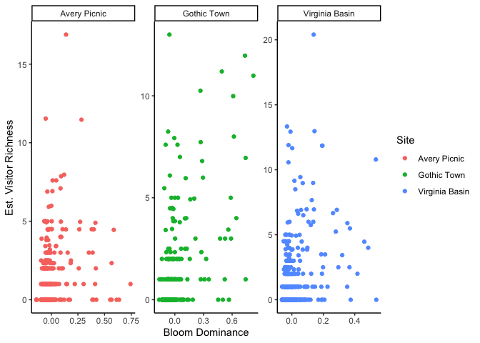

```r
library(ggplot2)

ggplot(all.info3, aes(x = delta.prop, y = Estimator, color = Site)) +
  geom_point() +
  ylab("Est. Visitor Richness") +
  xlab("Bloom Dominance") +
  theme_classic() +
  facet_wrap(~Site, scales = 'free')
```

Proportional number of total visits vs. dominance

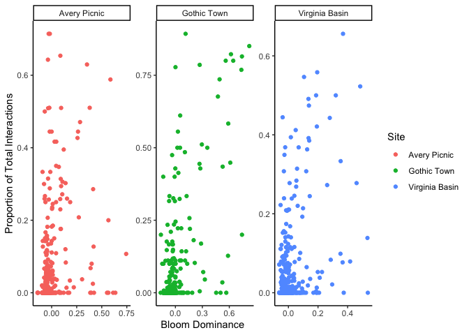

```r
ggplot(all.info3, aes(x = delta.prop, y = p.intxns, color = Site)) +
  geom_point() +
  ylab("Proportion of Total Interactions") +
  xlab("Bloom Dominance") +
  theme_classic() +
  facet_wrap(~Site, scales = 'free')
```

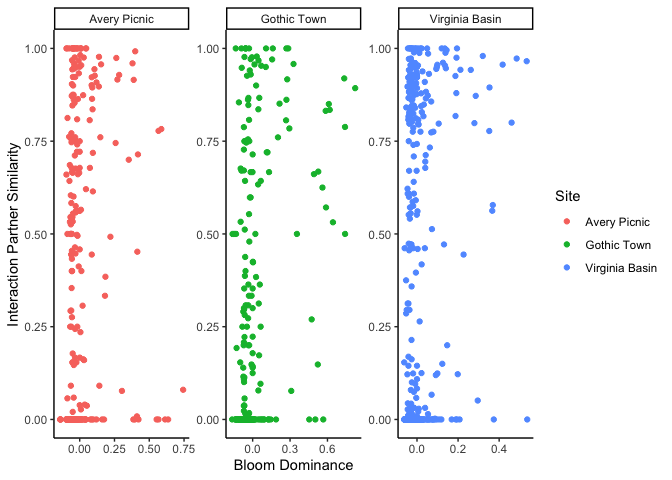

```r
ggplot(all.info3, aes(x = delta.prop, y = sim, color = Site)) +
  geom_point() +
  ylab("Interaction Partner Similarity") +
  xlab("Bloom Dominance") +
  theme_classic() +
  facet_wrap(~Site, scales = 'free')
```

Okay those look terrible – but might look better once the pollinator data is more resolveds

Species strength vs. dominance

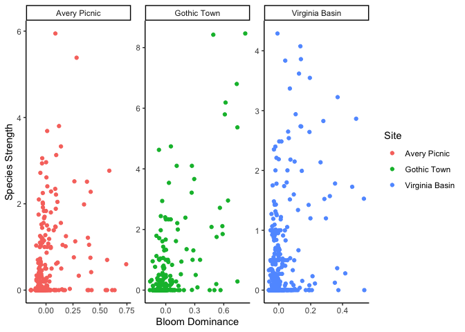

```r
ggplot(all.info3, aes(x = delta.prop, y = species.strength, color = Site)) +
  geom_point() +
  ylab("Species Strength") +
  xlab("Bloom Dominance") +
  theme_classic() +
  facet_wrap(~Site, scales = 'free')
```

There’s one thing that I kind of feel like can be taken out and that’s the plants that had no interactions. I know it’s kind of weird because if it had a bloom and no interactions then that’s data but I guess they’re not important to the network? I don’t know…

Remove the species that had no interactions

```r
all.info4 <- all.info3[which(all.info3$Observed != 0), ]
```

Estimated visitor richness vs. dominance

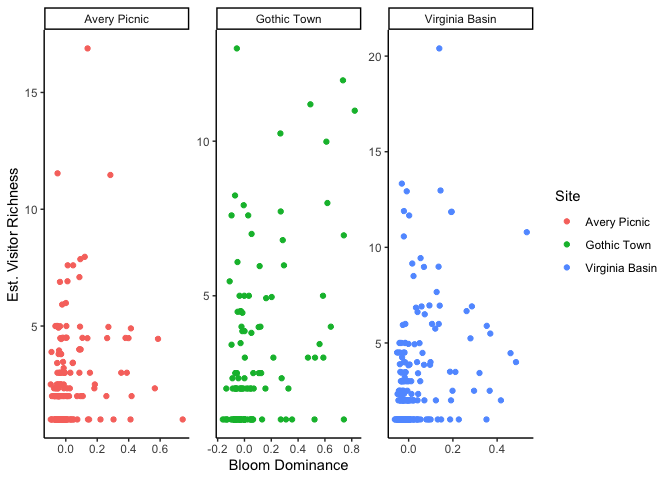

```r
ggplot(all.info4, aes(x = delta.prop, y = Estimator, color = Site)) +
  geom_point() +
  ylab("Est. Visitor Richness") +
  xlab("Bloom Dominance") +
  theme_classic() +
  facet_wrap(~Site, scales = 'free')
```

Proportional number of total visits vs. dominance

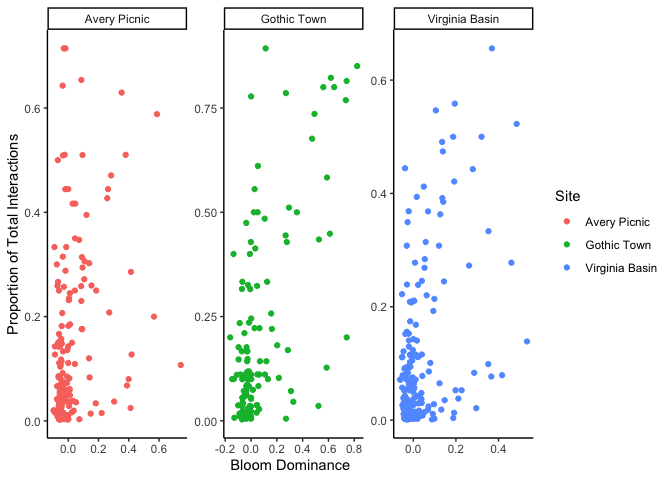

```r
ggplot(all.info4, aes(x = delta.prop, y = p.intxns, color = Site)) +
  geom_point() +
  ylab("Proportion of Total Interactions") +
  xlab("Bloom Dominance") +
  theme_classic() +
  facet_wrap(~Site, scales = 'free')
```

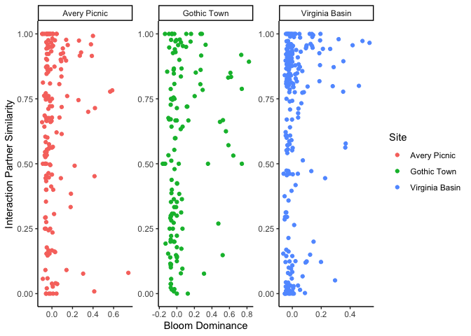

```r
ggplot(all.info4, aes(x = delta.prop, y = sim, color = Site)) +
  geom_point() +
  ylab("Interaction Partner Similarity") +
  xlab("Bloom Dominance") +
  theme_classic() +
  facet_wrap(~Site, scales = 'free')
```

Species strength vs. dominance

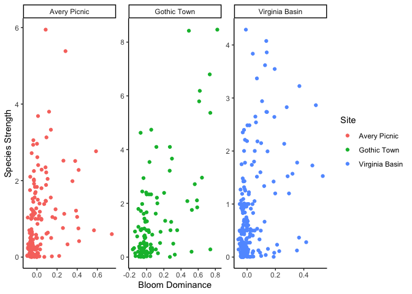

```r
ggplot(all.info4, aes(x = delta.prop, y = species.strength, color = Site)) +
  geom_point() +
  ylab("Species Strength") +
  xlab("Bloom Dominance") +
  theme_classic() +
  facet_wrap(~Site, scales = 'free')
```

## Top Species

Okay that was looking at all the species at once, but what if I want to look at the top species? Because most species are rare, and therefor hard to say for sure how many partners they really have. So let’s pick the top three most dominant blooming species from each site (based on number of blooms alone, at first).

Pull out the top three blooms

```r
## here you want to work with the all.blooms.wide data

## function to pick the top three most abundant blooms at the site on that date and time (using the all.blooms.wide dataframes)
top.three.fun <- function(df) {
  df[order(as.integer(df), decreasing = T)][1:3]
}

## extract the top three blooms for each site_date combo
top.three.blooms <- lapply(all.blooms.wide, function(list) {lapply(list, top.three.fun)})
```

We have the top three blooms from each site and data combo and now we need the rest of the information for those plant species, which we can get from all.info

```r
names(top.three.blooms[[1]][[1]])
```

```
## [1] "Delphinium barbeyi"         "Hymenoxys hoopesii"
## [3] "Helianthella quinquenervis"
```

```r
top.three.pick <- function(x, y) {t3n <- names(x)
  new.y <- y[which(y$species %in% t3n), ]
  return(new.y)}

## now is the information for the species of interest only
t3.info <- mapply(function(z, y) {mapply(top.three.pick, z, y, SIMPLIFY = F)}, top.three.blooms, all.info)
```

And we can make the same graphs with these more bloom dominant species

But first join the different dates together within each site

We’ll pool the observations across dates for each site, and plot the info per site separately

```r
t3.info2 <- lapply(t3.info, function(list) {do.call(rbind, list)})

## add identifying site information in this kind of janky way
for(i in 1:length(t3.info2)) {
  t3.info2[[i]]$Site <- rep(names(t3.info2)[i], nrow(t3.info2[[i]]))
}

t3.info3 <- do.call(rbind, t3.info2)
```

Estimated visitor richness vs. dominance

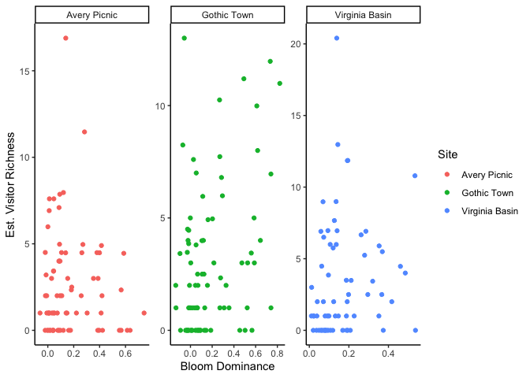

```r
ggplot(t3.info3, aes(x = delta.prop, y = Estimator, color = Site)) +
  geom_point() +
  ylab("Est. Visitor Richness") +
  xlab("Bloom Dominance") +
  theme_classic() +
  facet_wrap(~Site, scales = 'free')
```

Proportional number of total visits vs. dominance

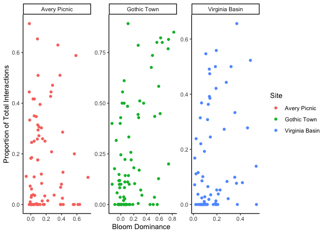

```r
ggplot(t3.info3, aes(x = delta.prop, y = p.intxns, color = Site)) +
  geom_point() +
  ylab("Proportion of Total Interactions") +
  xlab("Bloom Dominance") +
  theme_classic() +
  facet_wrap(~Site, scales = 'free')
```

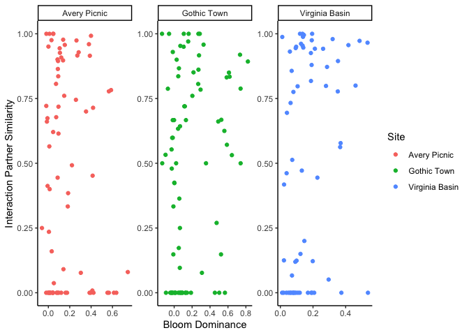

```r
ggplot(t3.info3, aes(x = delta.prop, y = sim, color = Site)) +
  geom_point() +
  ylab("Interaction Partner Similarity") +
  xlab("Bloom Dominance") +
  theme_classic() +
  facet_wrap(~Site, scales = 'free')
```

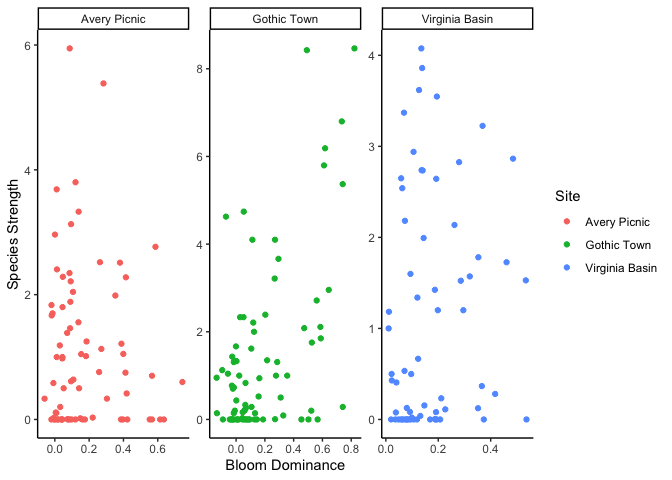

```r
ggplot(t3.info3, aes(x = delta.prop, y = species.strength, color = Site)) +
  geom_point() +
  ylab("Species Strength") +
  xlab("Bloom Dominance") +
  theme_classic() +
  facet_wrap(~Site, scales = 'free')
```